# DATA607 Final

Gabriella Martinez, Maliat Islam, Gabriel Campos

May 27 2021

# Assignment

## Requirements

$MSDA\ 607\ Final\ Project$

Deliverables Schedule

| *Deliverable* | *Date* | *Points* |
| --- | --- | --- |
| One Paragraph Proposal | Sunday April 26 | 20 |
| Final Project | Wednesday May 19 | 120 |
| Final Project Presentation | Before or during Final Meetup on Wednesday May 19 | 30 |

Policy on Collaboration

You may work in a team of up to three people. Each project team member is responsible for understanding and being able to explain all of the submitted project code. Remember that you can take work that you find elsewhere as a base to build on, but you need to acknowledge the source, so that I base your grade on what you contributed, not on what you started with!

Approval Meeting

Once you’ve turned in your one paragraph proposal, I want to schedule a 15 minute phone meeting with each person or team (starting when we return from Thanksgiving break), where you’ll describe the reason (benefit) for doing this work and/or question you’re seeking to answer, where you’ll source the data, and the overall flow. For team projects, I also want you to articulate the roles and responsibilities of each team member.

Final Project Checklist

To receive full credit, you’ll need to deliver on all of the items in the checklist below. Please read carefully through this checklist before you make your project proposal. You are (within these checklist constraints) strongly urged to limit scope and make the necessary simplifying assumptions so that you can deliver your work on time!

- Proposal describes your motivation for performing this analysis
- Proposal describes likely data sources.
- Your project has a recognizable “data science workflow,” such as the OSEMN work flow or Hadley Wickham’s Grammar of Data Science. [Example: First the data is acquired, then necessary transformations and clean-up are performed, then the analysis and presentation work is performed]
- Project includes data from at least two different types of data sources (e.g., two or more of these: relational or CSV,Neo4J, **web page [scraped or API]**, MongoDB, etc.)
- Project includes at least one data transformation operation. [Examples: transforming from wide to long; converting columns to date format]
- Project includes at least one statistical analysis and at least one graphics that describes or validates your data.
- Project includes at least one graphic that supports your conclusion(s).
- Project includes at least one statistical analysis that supports your conclusion(s).
- Project includes at least one feature that we did not cover in class! There are many examples: “I used ggmap; I created a decision tree; I ranked the results; I created my presentation slides directly from R; I figured out to use OAuth 2.0…”
- Presentation. Was the presentation delivered in the allotted time (3 to 5 minutes)?
- Presentation. Did you show (at least) one challenge you encountered in code and/or data, and what you did when you encountered that challenge? If you didn’t encounter any challenges, your assignment was clearly too easy for you!
- Presentation. Did the audience come away with a clear understanding of your motivation for undertaking the project?
- Presentation. Did the audience come away with a clear understanding of at least one insight you gained or conclusion you reached or hypothesis you “confirmed” (rejected or failed to reject…)?
- Code and data. Have you delivered the submitted code and data where it is self-contained—preferably in rpubs.com and github? Am I able to fully reproduce your results with what you’ve delivered? You won’t receive full credit if your code references data on your local machine!
- Code and data. Does all of the delivered code run without errors?
- Code and data. Have you delivered your code and conclusions using a “reproducible research” tool such as RMarkdown?
- Deadline management. Were your draft project proposal, project, and presentation delivered on time? Any part of the project that is turned in late will receive a maximum grade of 80%. Please turn in your work on time! You are of course welcome to deliver ahead of schedule!

## Scope

[figure not shown]

With COVID-19 impacting employment worldwide, many articles have been published highlighting the toll it has taken on specific demographics. Our motivation to dive deeper into the impact by demographic, has been influenced by articles such as [**COVID-19 has spurred America’s first female recession**](https://www.pbs.org/newshour/economy/COVID-19-has-spurred-americas-first-female-recession). This article talk about the negative affect the pandemic has had on women in the United States. Using data from the [U.S. Bureau of Labor Statistics](https://www.bls.gov/), we hope to identify if the impact was disproportionate or great to women vs. men.

## Data Preparation

### Load Data

In order to conduct our studies we used data from [U.S. Bureau of Labor Statistics | Labor Force Statistics from the Current Population Survey](https://www.bls.gov/cps/tables.htm#empstat) specifically data regarding:

- [Table 9 : *Unemployed persons by age, sex, and marital status, seasonally adjusted*](https://www.bls.gov/web/empsit/cpseea09.htm)
- [Table 10: *Unemployment rates by age, sex, and marital status, seasonally adjusted*](https://www.bls.gov/web/empsit/cpseea10.htm)
- [Table 30: *Unemployed persons by occupation and sex*](https://www.bls.gov/web/empsit/cpseea30.htm)

The data was **web scraped** then encapsulated using the functions `as.dataframe()`, `html_table()` and `read_html`, then subsetted.

```r
url_9  <- "https://www.bls.gov/web/empsit/cpseea09.htm"
url_10 <- "https://www.bls.gov/web/empsit/cpseea10.htm"
url_30 <- "https://www.bls.gov/web/empsit/cpseea30.htm"
```

Table 9 Data

```r
head(df_tb9  <- as.data.frame(html_table(read_html(url_9))[[2]]),5)%>%
  reactable(highlight = TRUE, pagination = FALSE, height = 450)
```

[output not shown]

________________________________________________________________________________

Table 10 Data

```r
head(df_tb10 <- as.data.frame(html_table(read_html(url_10))[[2]]),5)%>%
  reactable(highlight = TRUE, pagination = FALSE, height = 450)
```

[output not shown]

Table 30 Data

```r
head(df_tb30 <- as.data.frame(html_table(read_html(url_30))[[2]]),10)%>%
  reactable(highlight = TRUE, pagination = TRUE, height = 850)
```

| Occupation | Total unemployed | Total unemployed | Unemployment rates | Unemployment rates | Unemployment rates | Unemployment rates | Unemployment rates | Unemployment rates |
| --- | --- | --- | --- | --- | --- | --- | --- | --- |
| Occupation | Apr.2020 | Apr.2020 | Total | Total | Total | Total | Total | Total |
| Occupation | Apr.2020 | Apr.2020 | Apr.2020 | Apr.2020 | Apr.2020 | Apr.2020 | Apr.2020 | Apr.2020 |
| Total, 16 years and over(1) | 22,504 | 22,504 | 14.4 | 14.4 | 14.4 | 14.4 | 14.4 | 14.4 |
| Management, professional, and related occupations | 5,079 | 5,079 | 7.7 | 7.7 | 7.7 | 7.7 | 7.7 | 7.7 |
| Management, business, and financial operations occupations | 1,742 | 1,742 | 6.2 | 6.2 | 6.2 | 6.2 | 6.2 | 6.2 |
| Management occupations | 1,199 | 1,199 | 6.3 | 6.3 | 6.3 | 6.3 | 6.3 | 6.3 |
| Business and financial operations occupations | 543 | 543 | 6.0 | 6.0 | 6.0 | 6.0 | 6.0 | 6.0 |
| Professional and related occupations | 3,337 | 3,337 | 8.8 | 8.8 | 8.8 | 8.8 | 8.8 | 8.8 |
| Computer and mathematical occupations | 257 | 257 | 4.3 | 4.3 | 4.3 | 4.3 | 4.3 | 4.3 |

### Transform Data

Data manipulation and *tidying* for `Table 9` included:

- relabeling column values to reflect a *(4 digit: year)* **-** *(2 digit: month)* (`%y%m`) format.
- subsetting data frames to remove unnecessary data or blank rows with the help of piping `%>%`
- categorizing data with a `Gender` column, that included a `Male`,`Female` and `Total` value respectively.

  **Note:** Total value was used to specify data that reflects total unemployment counts.

```r
colnames(df_tb10) <- c("Label","2020-03", "2020-04",
                         "2020-05", "2020-06", "2020-07",
                         "2020-08", "2020-09", "2020-10",
                         "2020-11", "2020-12","2021-01",
                         "2021-02", "2021-03")


colnames(df_tb9) <- c("Label", "2020-03", "2020-04",
                         "2020-05", "2020-06", "2020-07",
                         "2020-08", "2020-09", "2020-10",
                         "2020-11", "2020-12","2021-01",
                         "2021-02", "2021-03")
```

```r
df_tb9_tdy<-
    as.data.frame(df_tb9[1,]%>%
      assign_in(list(1,1),"Month")%>%
        bind_rows(df_tb9[3:14,],
          df_tb9[16:27,],
          df_tb9[29:40,])
    )
# Adding male and female category
df_tb9_tdy$Gender<-"Total"
df_tb9_tdy$Gender[14:25] <- "Male"
df_tb9_tdy$Gender[26:37] <- "Female"
```

And repeated for `Table 10`.

```r
df_tb10_tdy<-
    as.data.frame(df_tb10[1,]%>%
      assign_in(list(1,1),"Month")%>%
        bind_rows(df_tb10[3:14,],
          df_tb10[16:27,],
          df_tb10[29:40,])
    )

# Adding male and female category
df_tb10_tdy$Gender<-"Total"
df_tb10_tdy$Gender[14:25] <- "Male"
df_tb10_tdy$Gender[26:37] <- "Female"
```

This *tidy* data (`df_tb9_tdy`,`df_tb10_tdy`) is the baseline used for our evaluation of the comparison between unemployment rates of men and women, during the beginning month until present day, of the pandemic.

Using [**ZevRoss: Know Your Data | Easy multi-panel plots in R using facet_wrap() and facet_grid() from ggplot2**](http://zevross.com/blog/2019/04/02/easy-multi-panel-plots-in-r-using-facet_wrap-and-facet_grid-from-ggplot2/) as a point of reference, we continue to transform the data.

Specifically:

- `regex` is used within the `gsub()` function, to remove `,` from our `Rate` column.
- `Month` and `Rate` is then transformed to data types that will allow for further analysis.

```r
#Dependency on df_tb10_tdy    Rate, Gender, Age Group
df_tb10_ln <- as.data.frame(df_tb10_tdy %>%
  slice(c(16,17,19,22,23,24,25,28,29,31,34,35,36,37)) %>%
    gather("Month_Year", "Rate", 2:14)%>%
      lapply(function(x){
        gsub(",", "", x)}))
```

```r
df_tb10_ln$Month_Year<- as.yearmon(df_tb10_ln$Month_Year)
df_tb10_ln$Rate <- as.numeric(df_tb10_ln$Rate)
```

| Label | Gender | Month_Year | Rate |
| --- | --- | --- | --- |
| 18 to 19 years | Female | Mar 2020 | 38.7 |
| 16 to 17 years | Female | Mar 2020 | 33.3 |
| 16 to 17 years | Female | Apr 2020 | 31.0 |
| 18 to 19 years | Male | Mar 2020 | 30.7 |
| 18 to 19 years | Female | Apr 2020 | 30.3 |
| 18 to 19 years | Male | Apr 2020 | 28.8 |

From here we calculate rates and store the values to `df_tb9_rt`. The data is transformed in a month over month format, so that it can be assessed as a trend throughout the year. The functions used to create this data frame included:

- piping `%>%`
- `slice()`
- `gather()`
- `mutate()`

This data frame is grouped by `Gender` specifically.

Dates and counts are converted with `as.yearmon()` & `as.numeric()`.

where [`lag()`](https://www.rdocumentation.org/packages/stats/versions/3.6.2/topics/lag) is a time series shift from the `stats` package.

```r
# Month over Month employment rate change by gender
#Dependency on df_tb9_tdy:     Rate and Gender
df_tb9_rt <- df_tb9_tdy %>%
  slice(c(14,26)) %>%
    gather("Month_Year", "Count", 2:14)

df_tb9_rt$Month_Year<- as.yearmon(df_tb9_rt$Month_Year)
df_tb9_rt$Count <- as.numeric(gsub(",","",df_tb9_rt$Count))

df_tb9_rt <-
    df_tb9_rt %>%
      group_by(Gender) %>%
        mutate(MoM = (Count - lag(Count)) / lag(Count)) %>%
          mutate(MoM_Rate =  round(MoM * 100, 2))
```

The result is a data frame with rates for ages *16 and over* (or all age groups).

| Label | Gender | Month_Year | Count | MoM | MoM_Rate |
| --- | --- | --- | --- | --- | --- |
| Women, 16 years and over | Female | Nov 2020 | 5042 | 0.0430285 | 4.30 |
| Men, 16 years and over | Male | Mar 2021 | 5394 | 0.0301757 | 3.02 |
| Men, 16 years and over | Male | Jan 2021 | 5395 | -0.0071770 | -0.72 |
| Men, 16 years and over | Male | Oct 2020 | 5894 | -0.0107419 | -1.07 |
| Women, 16 years and over | Female | Mar 2021 | 4418 | -0.0125168 | -1.25 |
| Women, 16 years and over | Female | Feb 2021 | 4474 | -0.0225038 | -2.25 |

Following a similar approach, but grouping by `Gender` & `Label` we create data frame `df_tb9_MoM` and can see the impact for each age bracket.

```r
# Month over Month employment rate change by age and gender
#Dependency on df_tb9_tdy:     Count, age, and Gender

df_tb9_MoM <- df_tb9_tdy %>%
  slice(c(16,17,19,22,23,24,25,28,29,31,34,35,36,37)) %>%
  gather("Month_Year", "Count", 2:14)

df_tb9_MoM$Month_Year<- as.yearmon(df_tb9_MoM$Month_Year)
df_tb9_MoM$Count <- as.numeric(gsub(",","",df_tb9_MoM$Count))

df_tb9_MoM <- df_tb9_MoM %>%
  group_by(Gender, Label) %>%
  mutate(MoM = (Count - lag(Count)) / lag(Count)) %>%
  mutate(MoM_Rate =  round(MoM * 100, 1))
```

| Label | Gender | Month_Year | Count | MoM | MoM_Rate |
| --- | --- | --- | --- | --- | --- |
| 16 to 17 years | Male | Oct 2020 | 146 | -0.1360947 | -13.6 |
| 16 to 17 years | Female | Oct 2020 | 168 | 0.2923077 | 29.2 |
| 16 to 17 years | Male | Nov 2020 | 159 | 0.0890411 | 8.9 |
| 16 to 17 years | Female | Nov 2020 | 143 | -0.1488095 | -14.9 |
| 16 to 17 years | Male | Dec 2020 | 157 | -0.0125786 | -1.3 |
| 16 to 17 years | Female | Dec 2020 | 180 | 0.2587413 | 25.9 |
| 16 to 17 years | Male | Jan 2021 | 175 | 0.1146497 | 11.5 |
| 16 to 17 years | Female | Jan 2021 | 149 | -0.1722222 | -17.2 |
| 16 to 17 years | Male | Feb 2021 | 143 | -0.1828571 | -18.3 |
| 16 to 17 years | Female | Feb 2021 | 135 | -0.0939597 | -9.4 |
| 16 to 17 years | Male | Mar 2021 | 126 | -0.1188811 | -11.9 |

For our linear trend analysis `df_tb10_trend` is created for an additional perspective of unemployment by demographic by year.

```r
#Dependency on df_tb10_tdy:     Rate and Gender
#data transformation operation: from wide to long function: gather, package: tidyr
df_tb10_trend <- df_tb10_tdy %>%
  slice(c(14,26)) %>%
  gather("Month_Year", "Rate", 2:14)

#data transformation operation: date format function: as.yearmon, package: zoo
df_tb10_trend$Month_Year<- as.yearmon(df_tb10_trend$Month_Year)
df_tb10_trend$Rate <- as.numeric(df_tb10_trend$Rate)
```

| Label | Gender | Month_Year | Rate |
| --- | --- | --- | --- |
| Men, 16 years and over | Male | Mar 2020 | 13.6 |
| Women, 16 years and over | Female | Mar 2020 | 16.1 |
| Men, 16 years and over | Male | Apr 2020 | 12.2 |
| Women, 16 years and over | Female | Apr 2020 | 14.5 |
| Men, 16 years and over | Male | May 2020 | 10.5 |

Because the format of table 30 was slightly different from the latter, information it was *tidied* using the same overview but accounting for the specific rows and columns we required.

```r
df_tb30 <-
  as.data.frame(
    bind_rows(df_tb30[3,]
              ,df_tb30[5:33,])%>%
      select(-2,-3)%>%
                lapply(function(x){
                   gsub(" occupations", "", x)}
                        ))%>%
  `colnames<-`(c("Occupation_Label",
                 "Total_Unemployed_Rates_April_2020",
    "Total_Unemployed_Rates_April_2021", "Men_Unemployment_Rate_2020",
    "Men_Unemployment_Rate_2021", "Women_Unemployment_Rate_2020",
    "Women_Unemployment_Rate_2021"))
```

Industries are categorized as primary industry categories and sub categories in the original `HTML` file shown below

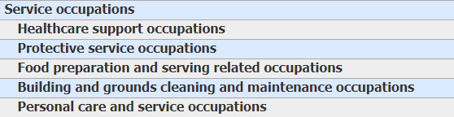

- `df_tb30_full` : noting all main and sub industry names
- `df_tb30_sub` : noting only the primary categories
- `df_tb30_rc` : including rate change

`Gender_Year` column is created in the transformation with rate being transformed into a single column.

```r
# All categories
df_tb30_full<-as.data.frame(df_tb30 %>%
  select(-2,-3)%>%
    slice(c(2:30)) %>%
      gather("Gender_Year", "Rate", 2:5))%>%
        mutate(Rate = as.numeric(Rate))
# Only Primary categories
df_tb30_sub<-as.data.frame(df_tb30 %>%
  select(-2,-3)%>%
    slice(c(3,6,15,21,24,28)) %>%
      gather("Gender_Year", "Rate", 2:5))%>%
        mutate(Rate = as.numeric(Rate))
```

An if else statement is used, referencing `Gender_Year` to categorize gender in our results.

```r
df_tb30_full$Gender<-
  ifelse(grepl("Men", df_tb30_full$Gender_Year), "Male",
               ifelse(grepl("Women", df_tb30_full$Gender_Year), "Female", ""))

df_tb30_sub$Gender<-
  ifelse(grepl("Men", df_tb30_sub$Gender_Year), "Male",
         ifelse(grepl("Women", df_tb30_sub$Gender_Year), "Female", ""))
```

The `Year` column is added to `df_tb30_sub` using case_when() and [endsWith()](https://www.marsja.se/r-add-column-to-dataframe-based-on-other-columns-conditions-dplyr/)

```r
df_tb30_sub <-
  df_tb30_sub %>%
  mutate(Year = case_when(
    endsWith(Gender_Year, "2020") ~ "2020",
    endsWith(Gender_Year, "2021") ~ "2021"))
```

In order to create `Rate_Change` in `df_tb30_rc` we used the following calculation in `mutate()`:

$\frac{2021-2020}{2020} \times 100$

```r
df_tb30_rc<-
  df_tb30_sub %>%
    select(- 2) %>%
      spread(Year,Rate)

df_tb30_rc<-df_tb30_rc%>%
  mutate(Rate_Change =
    round((((df_tb30_rc$'2021' - df_tb30_rc$'2020')/df_tb30_rc$'2020')*100),2))
```

The resulting data frames are as follows:

**df_tb30_full**

| Occupation_Label | Gender_Year | Rate | Gender |
| --- | --- | --- | --- |
| Management, professional, and related | Men_Unemployment_Rate_2020 | 6.6 | Male |
| Management, business, and financial operations | Men_Unemployment_Rate_2020 | 5.8 | Male |
| Management | Men_Unemployment_Rate_2020 | 5.9 | Male |
| Business and financial operations | Men_Unemployment_Rate_2020 | 5.3 | Male |
| Professional and related | Men_Unemployment_Rate_2020 | 7.3 | Male |
| Computer and mathematical | Men_Unemployment_Rate_2020 | 4.2 | Male |
| Architecture and engineering | Men_Unemployment_Rate_2020 | 5.2 | Male |
| Life, physical, and social science | Men_Unemployment_Rate_2020 | 7.1 | Male |
| Community and social service | Men_Unemployment_Rate_2020 | 5.1 | Male |
| Legal | Men_Unemployment_Rate_2020 | 4.8 | Male |

**df_tb30_sub**

| Occupation_Label | Gender_Year | Rate | Gender | Year |
| --- | --- | --- | --- | --- |
| Management, business, and financial operations | Men_Unemployment_Rate_2020 | 5.8 | Male | 2020 |
| Professional and related | Men_Unemployment_Rate_2020 | 7.3 | Male | 2020 |
| Service | Men_Unemployment_Rate_2020 | 23.6 | Male | 2020 |
| Sales and office | Men_Unemployment_Rate_2020 | 12.6 | Male | 2020 |
| Natural resources, construction, and maintenance | Men_Unemployment_Rate_2020 | 16.2 | Male | 2020 |
| Production, transportation, and material moving | Men_Unemployment_Rate_2020 | 17.4 | Male | 2020 |
| Management, business, and financial operations | Men_Unemployment_Rate_2021 | 2.9 | Male | 2021 |
| Professional and related | Men_Unemployment_Rate_2021 | 3.1 | Male | 2021 |
| Service | Men_Unemployment_Rate_2021 | 8.2 | Male | 2021 |
| Sales and office | Men_Unemployment_Rate_2021 | 5.6 | Male | 2021 |

**df_tb30_rc**

| Occupation_Label | Gender | 2020 | 2021 | Rate_Change |
| --- | --- | --- | --- | --- |
| Management, business, and financial operations | Female | 6.7 | 3.4 | -49.25 |
| Management, business, and financial operations | Male | 5.8 | 2.9 | -50.00 |
| Natural resources, construction, and maintenance | Female | 17.0 | 10.2 | -40.00 |
| Natural resources, construction, and maintenance | Male | 16.2 | 7.8 | -51.85 |
| Production, transportation, and material moving | Female | 21.1 | 9.0 | -57.35 |
| Production, transportation, and material moving | Male | 17.4 | 7.8 | -55.17 |
| Professional and related | Female | 9.9 | 2.9 | -70.71 |
| Professional and related | Male | 7.3 | 3.1 | -57.53 |
| Sales and office | Female | 16.1 | 5.6 | -65.22 |
| Sales and office | Male | 12.6 | 5.6 | -55.56 |
| Service | Female | 29.8 | 7.9 | -73.49 |
| Service | Male | 23.6 | 8.2 | -65.25 |

Finally for our analysis of married women vs. married men rates we utilize the rows 43 and 44 from `df_tb10` and transform in a similar fashion as the above data.

```r
df_tb10marital<-df_tb10[43:44,]
names(df_tb10marital)[1] <- "Marital Label"
df_tb10marital$`Marital Label`<- c("Male with Spouse Present","Female with Spouse Present")
df_tb10marital$Gender<-c("Male","Female")

df_tb10marital <-
  as.data.frame(df_tb10marital %>%
    gather("Month_Year", "Rate", 2:14))%>%
      mutate(Rate = as.numeric(Rate))%>%
        mutate(Month_Year = as.yearmon(Month_Year))
```

**df_tb10marital**

| Marital Label | Gender | Month_Year | Rate |
| --- | --- | --- | --- |
| Male with Spouse Present | Male | Mar 2020 | 9.6 |
| Female with Spouse Present | Female | Mar 2020 | 13.1 |
| Male with Spouse Present | Male | Apr 2020 | 8.2 |
| Female with Spouse Present | Female | Apr 2020 | 11.5 |
| Male with Spouse Present | Male | May 2020 | 6.9 |

### Exploratory Data Analysis

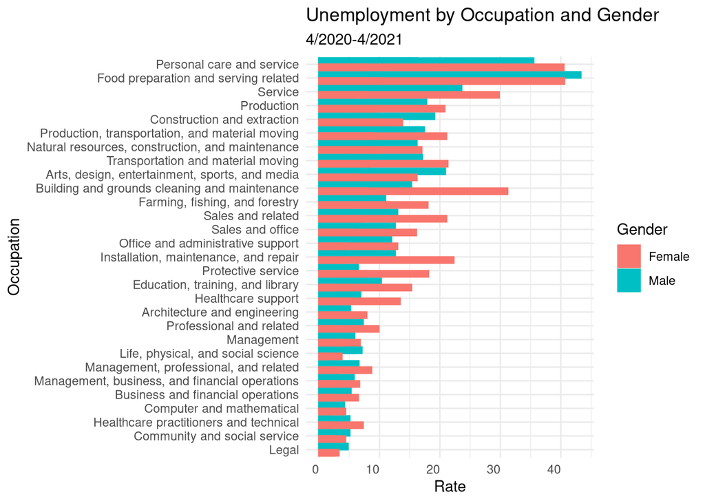

```r
ggplot(df_tb30_full, aes(x=fct_reorder(factor(Occupation_Label),Rate), y = (Rate),color = Gender,
                         group = Gender, fill=Gender)) +
  geom_col(position="dodge") +
  theme_minimal()+
  theme(axis.text.x = element_text( hjust=1))+
  labs(title = 'Unemployment by Occupation and Gender'
       ,subtitle = "4/2020-4/2021",
       x = "Occupation", y = "Rate")+
  coord_flip()
```

However when running `summary()` on our data, we see an low `R-squared` value of `0.0118`. This indicates that our data does not fit well in our regression model.

```r
#testing linear model. issue: gender is categorical var- need to look into this
# only accounts for 1.18% of data, Multiple R-squared:  0.0118
summary(lm(Count~Gender, df_tb9_rt))
```

```
##
## Call:
## lm(formula = Count ~ Gender, data = df_tb9_rt)
##
## Residuals:
##    Min     1Q Median     3Q    Max
##  -2123  -1627  -1095   1431   5293
##
## Coefficients:
##             Estimate Std. Error t value Pr(>|t|)
## (Intercept)   6540.8      634.3  10.312 2.69e-10 ***
## GenderMale     480.2      897.1   0.535    0.597
## ---
## Signif. codes:  0 '***' 0.001 '**' 0.01 '*' 0.05 '.' 0.1 ' ' 1
##
## Residual standard error: 2287 on 24 degrees of freedom
## Multiple R-squared:  0.0118, Adjusted R-squared:  -0.02938
## F-statistic: 0.2865 on 1 and 24 DF,  p-value: 0.5974
```

This fact is supported when running `plot()`, which results in various charts that we cannot used to support whether a relationship between unemployment and gender exists.

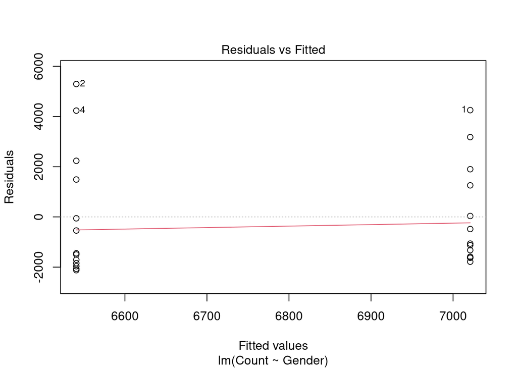

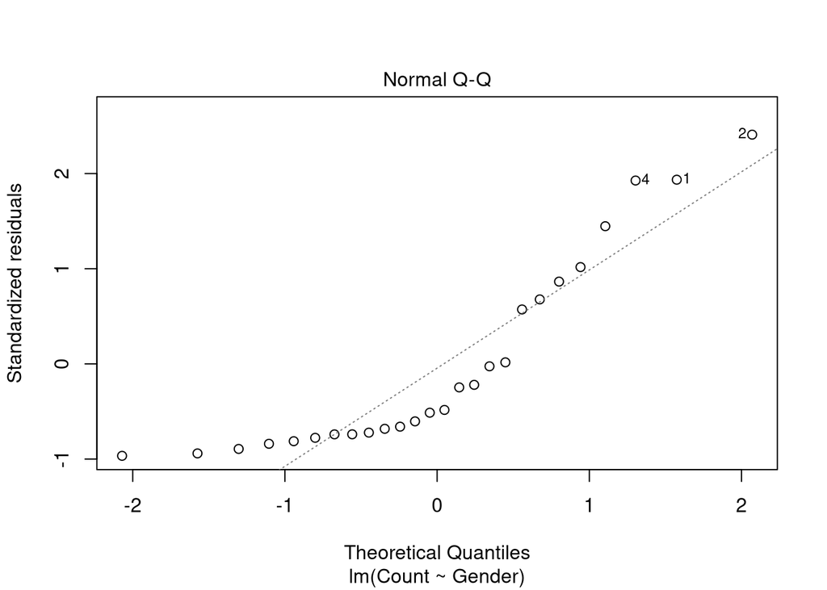

```
## hat values (leverages) are all = 0.07692308
##  and there are no factor predictors; no plot no. 5
```

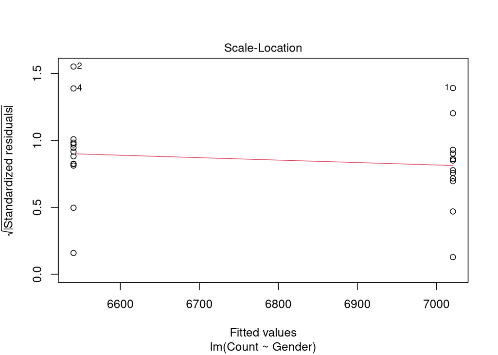

```r
plot(lm(Count~Gender, df_tb9_rt))
```

## Analysis

### Gender & Marital Status

**Marital Status and Unemployment Rate**

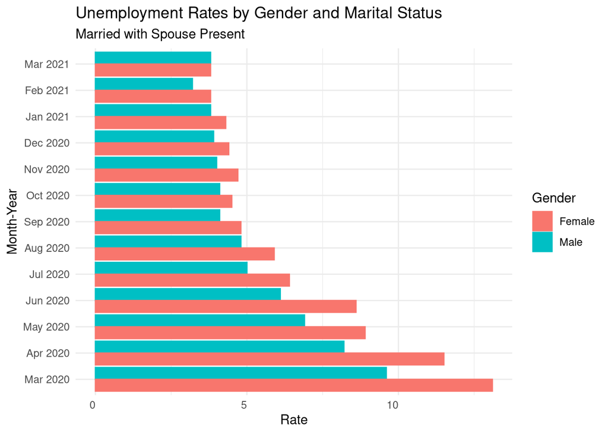

```r
ggplot(df_tb10marital, aes(x=factor(Month_Year), y = (Rate),color = `Gender`,
   group = `Gender`, fill=`Gender`)) +
   geom_col(position="dodge") +
   theme_minimal()+
   theme(axis.text.x = element_text(hjust=1))+
   labs(title = 'Unemployment Rates by Gender and Marital Status'
        ,subtitle = "Married with Spouse Present",
        x = "Month-Year", y = "Rate")+
   coord_flip()
```

### Gender & Age

#### Overall

We see that both male and females saw their largest unemployment spike in early March, women consistently having a higher rate monthly until about September 2020.

**df_tb10_trend**

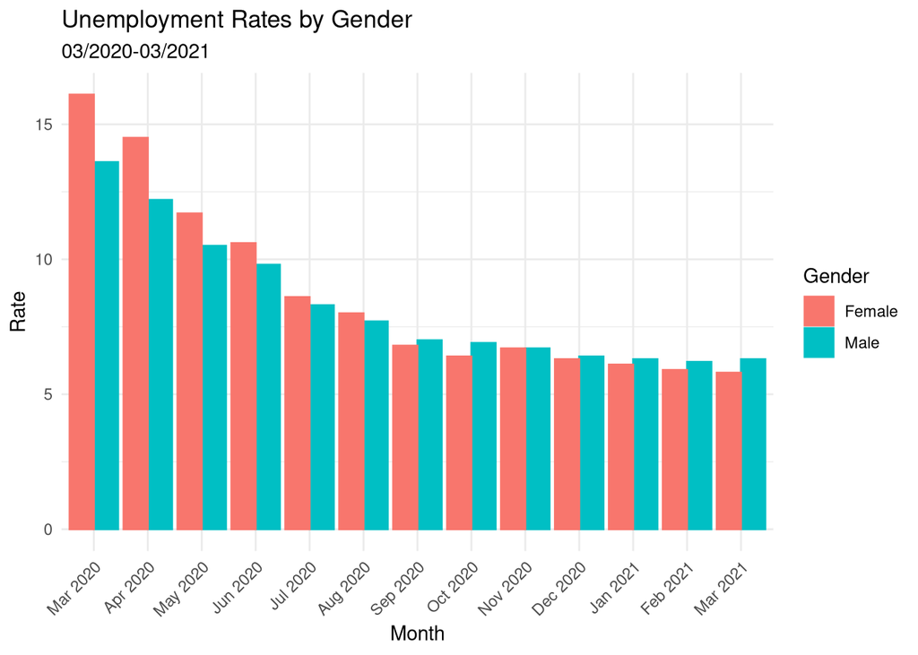

```r
ggplot(df_tb10_trend, aes(x=factor(Month_Year), y = (Rate),color = Gender,
                          group = Gender, fill=Gender)) +
  geom_col(position="dodge") +
  theme_minimal()+
  theme(axis.text.x = element_text(angle = 45, hjust=1))+
  labs(title = 'Unemployment Rates by Gender'
       ,subtitle = "03/2020-03/2021",
       x = "Month", y = "Rate")
```

**df_tb10_ln**

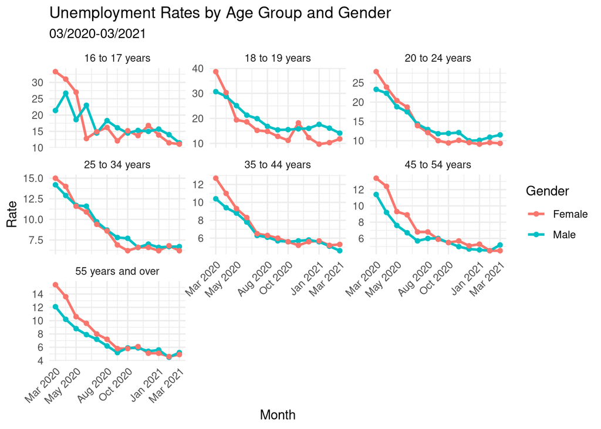

```r
(ggplot(data = df_tb10_ln, aes(Month_Year,Rate,color = Gender,group = Gender))+
  geom_line(size = 1) +
  geom_point() +
  theme_minimal()+
  theme(axis.text.x = element_text(angle = 45, hjust=1))+
  labs(title = 'Unemployment Rates by Age Group and Gender'
       ,subtitle = "03/2020-03/2021",
       x = "Month", y = "Rate")+
  facet_wrap( ~ Label, scales = "free_y"))
```

#### Month-over-month

Grouping and plotting our data by month, allows us to see the trend from March 2020 to March 2021. Doing so paints a clearer picture of the impact by demographic of COVID.

**df_tb9_rt**

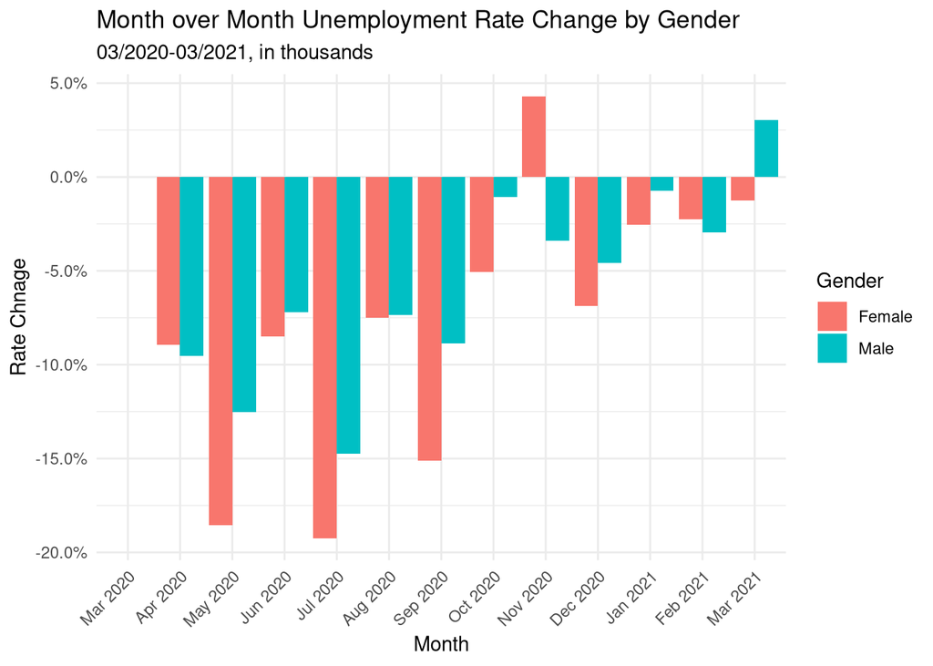

```r
ggplot(df_tb9_rt, aes(x=factor(Month_Year), y=MoM, fill=Gender)) +
  geom_col(position="dodge") +
  scale_y_continuous(labels = scales::percent)+
  theme_minimal()+
  theme(axis.text.x = element_text(angle = 45, hjust=1))+
  labs(title = 'Month over Month Unemployment Rate Change by Gender'
       ,subtitle = "03/2020-03/2021, in thousands",
       x = "Month", y = "Rate Chnage")
```

**df_tb9_MoM**

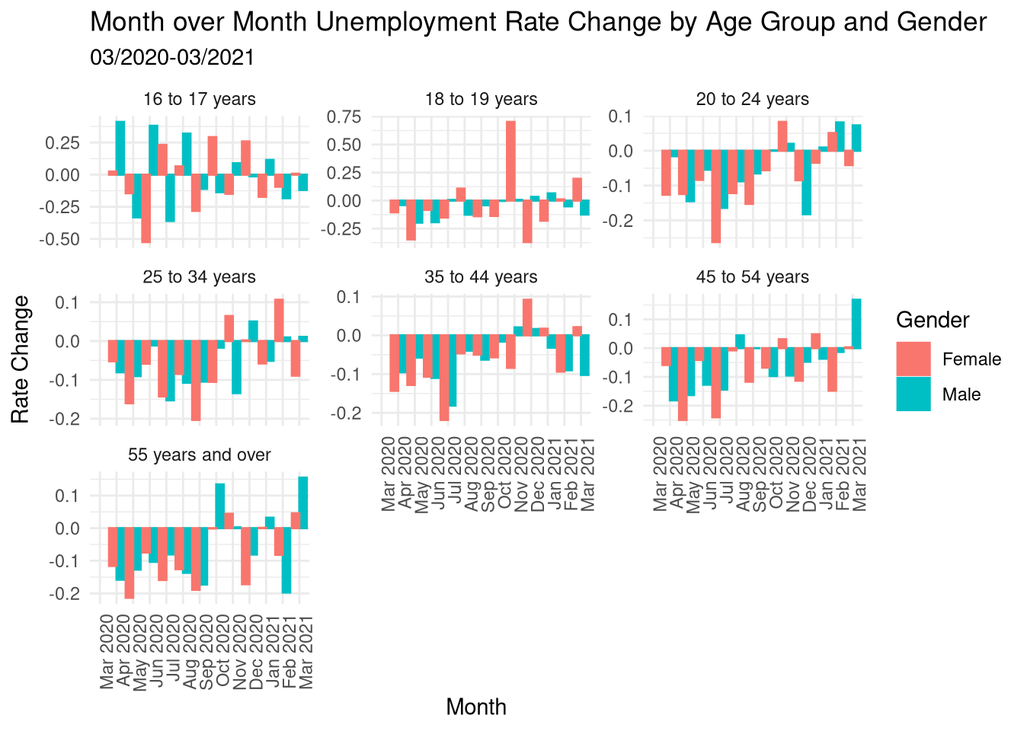

```r
##bar plot month over month age grp and geneder
(ggplot(df_tb9_MoM, aes(x=factor(Month_Year), y = (MoM), color = Gender,
                        group = Gender, fill=Gender)) +
  geom_col(position="dodge") +
  theme_minimal()+
  theme(axis.text.x = element_text(angle=90, hjust=1))+
  labs(title= 'Month over Month Unemployment Rate Change by Age Group and Gender',
       subtitle="03/2020-03/2021",
       x="Month", y="Rate Change")+
  facet_wrap( ~ Label, scales = "free_y"))
```

### Gender & Occupation

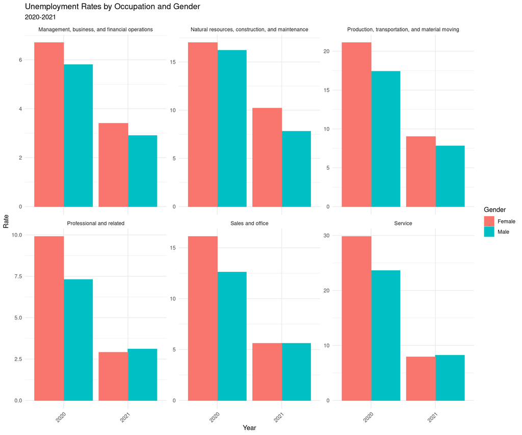

```r
(ggplot(data = df_tb30_sub, aes(Year, Rate, color = Gender,
                                group = Gender, fill = Gender)) +
  geom_col(position="dodge") +
  theme_minimal()+
  theme(axis.text.x = element_text(angle = 45, hjust=1))+
  labs(title = 'Unemployment Rates by Occupation and Gender'
       ,subtitle = "2020-2021",
       x = "Year", y = "Rate")+
  facet_wrap( ~ Occupation_Label, scales = "free_y",
              ncol = 3,labeller = labeller(Service = "Gender_Year")))
```

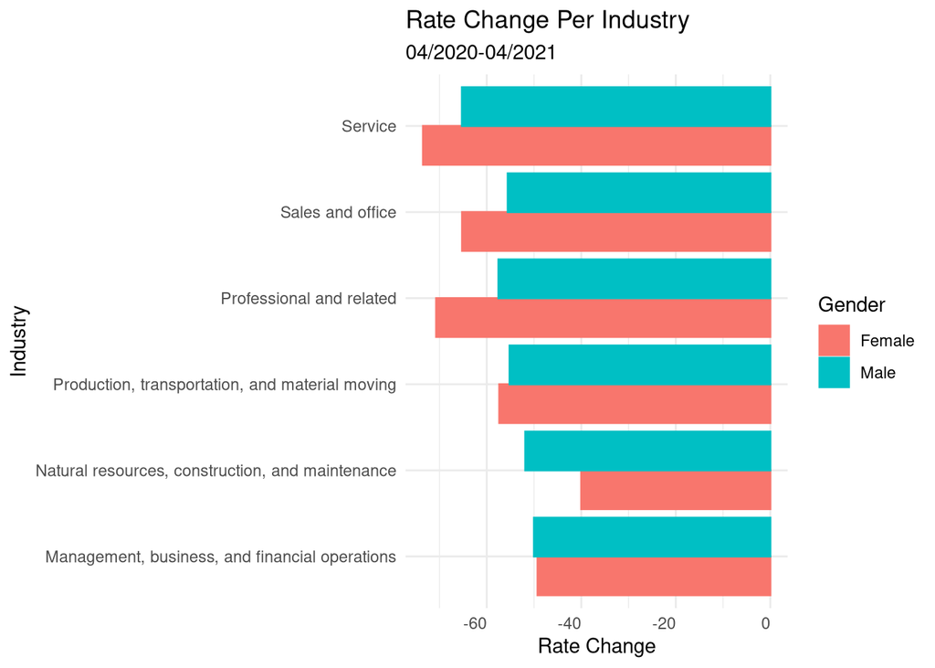

```r
##bar plot month over month age group and gender
ggplot(df_tb30_rc, aes(x=factor(Occupation_Label), y = (Rate_Change), color = Gender,
                        group = Gender, fill=Gender)) +
  geom_col(position="dodge") +
  theme_minimal()+
  theme(axis.text.x = element_text(hjust=1))+
  labs(title= 'Rate Change Per Industry',
       subtitle="04/2020-04/2021",
       x="Industry", y="Rate Change")+coord_flip()
```

## Conclusion

Our results support the title for the the article which inspired us, since it was published August 5,2020. At this point in the pandemic women were losing or leaving their jobs at a alarming rate. The concerns raised at the time were valid, and was at least 1 month away from producing data to supported the contrary. However, with the pandemic coming to a close (hopefully), we believe the trend should lean more favorably in women returning to the workforce.

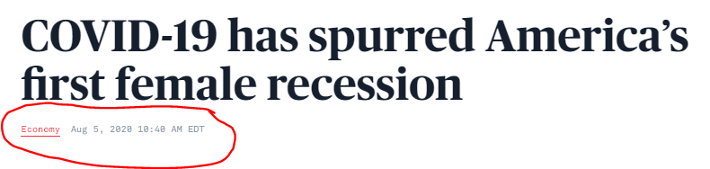